# PML Immune deconv

## Recap

The summary statistics and respective plots along with eSet creation is in `00_summstats_eset.{Rmd, html}`, imputation with random forest is in `01_pml_imp_summary.{Rmd, html}`, DimRed analysis is in `02_dimred_hvg.{Rmd, html}`, The differential expression analysis using DESeq2 along with significant marker info. is in `03_diffanalysis.{Rmd, html}` and the GSVA analysis from signatures coming from relevant datasets along with hypeR GSEA from the signatures is in `04_hyper_gsva_sigs.{Rmd, html}`. This file contains the immune deconvolution results from CIBERSORT with boxplots viz for grouped cell types(Innate and Adaptive) and their breakdown of sub cell-types.

```r
library(ggplot2)
library(stringr)
library(DT)
library(plyr)
library(dplyr)
library(biomaRt)
library(Biobase)
library(reshape2)
library(formattable)
library(VennDiagram)
library(hypeR)
library(xlsx)
library(DESeq2)
library(gridExtra)
library(ggsci)
PATH <- getwd()
```

# Read ExpressionSet object

```r
eset <- readRDS(file.path(PATH, "data/2021_08_20_eset_imputed_updated.RDS"))
eSet_wo_infl <- eset
table(eSet_wo_infl$Class)
```

```
##
##   Control Dysplasia      HkNR      OSCC
##        18        22        17         9
```

```r
eSet_wo_infl$Class <- recode(eSet_wo_infl$Class, "Cancer"="OSCC")
eSet_wo_infl$Class <- factor(eSet_wo_infl$Class, levels = c("Control", "HkNR", "Dysplasia", "OSCC"))

cpm_eset <- eSet_wo_infl
exprs(cpm_eset) <- apply(exprs(cpm_eset), 2, function(x) {x/(sum(x)/1000000)})
print(dim(cpm_eset))
```

```
## Features  Samples
##    21510       66
```

```r
cpm_eset$Class <- recode(cpm_eset$Class, "Control"="1-Control", "HkNR"="2-HkNR", "Dysplasia"="3-Dysplasia", "OSCC"="4-OSCC")
cpm_eset$Class <- factor(cpm_eset$Class, levels = c("1-Control", "2-HkNR", "3-Dysplasia", "4-OSCC"))
```

# Immune deconvolution

Using TPM counts(as recommended by immunedeconv & TIMER 2.0) immune deconvolution was performed. The resulting estimation matrix consists of enrichment/abundant scores from various methods such as xCell, CIBERSORT etc.,

The collective scores such as immune, stromal, microenvironment, cytotoxicity scores comes from xCell and MCPCounter.

```r
#setwd("~/Downloads/tpm/")
files = list.files(path = "~/Documents/Research/pml/pml_wo_infl/pml_tpm_wo_infl/", pattern=".tpm", full.names = TRUE)
tpm=read.table(file = files[1],row.names=1)

for (i in files[-1]){
  tmp=read.table(i,row.names=1)
  tpm=data.frame(tpm,tmp)
}

files1 = list.files(path = "~/Documents/Research/pml/pml_wo_infl/pml_tpm_wo_infl/", pattern=".tpm", full.names = FALSE)
colnames(tpm)=substr(files1,1,nchar(files1)-4)
write.table(tpm,file="~/Documents/Research/pml/pml_wo_infl/pml_tpm_wo_infl/tpm_combined_wo_infl.txt",quote=F,sep='\t')
```

The above .txt file consisting of TPM counts were inputted to [TIMER2.0 website](http://timer.cistrome.org)

```r
#using tpm counts
est <- read.csv(file.path(PATH, "results/estimation_matrix_wo_infl.csv"))
est1 <- est[grepl(est$cell_type, pattern = "_CIBERSORT-ABS"),]
est1$cell_type <- unlist(strsplit(est1$cell_type, split = "_CIBERSORT-ABS", fixed = TRUE))
est1 <- est1[!est1$cell_type %in% c( "immune score", "stroma score", "microenvironment score"),]

#filter only cell-types
est_mat <- as.matrix(est1[, colnames(est1)!='cell_type'])
rownames(est_mat) <- est1$cell_type
colnames(est_mat) <- gsub(colnames(est_mat), pattern = "\\.", replacement = "_")

#score specific data
est2 <- est[est$cell_type %in% c("immune score_XCELL", "stroma score_XCELL", "microenvironment score_XCELL", "cytotoxicity score_MCPCOUNTER"),]
est2$cell_type <- recode(est2$cell_type, "immune score_XCELL"="immune score", "microenvironment score_XCELL"="microenvironment score", "stroma score_XCELL"="stroma score", "cytotoxicity score_MCPCOUNTER"="cytotoxicity score")

est_mat2 <- as.matrix(est2[, colnames(est2)!='cell_type'])
rownames(est_mat2) <- est2$cell_type
colnames(est_mat2) <- gsub(colnames(est_mat2), pattern = "\\.", replacement = "_")
```

## ComplexHeatmap

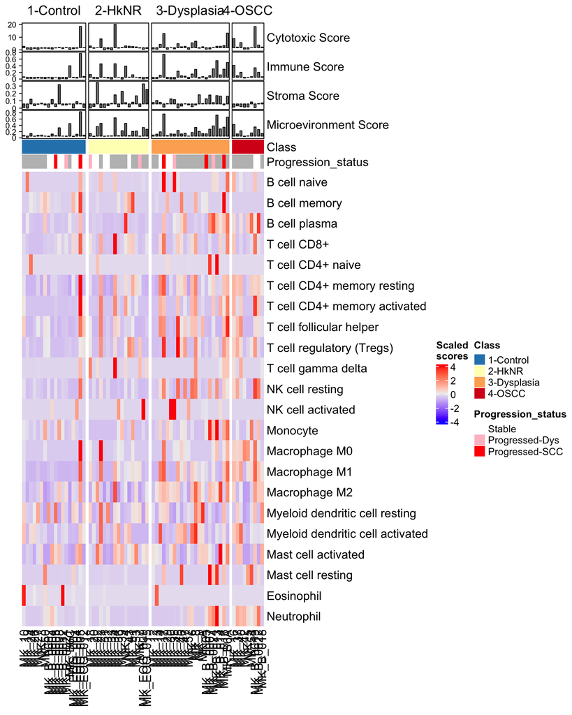

```r
library(ComplexHeatmap)
heatdata <- est_mat
heatdata <- t((scale(t(heatdata))))
heatmapkey <- paste("Scaled", "scores", sep = "\n")
condition <- c('Class')
column_ha = HeatmapAnnotation(`Cytotoxic Score` = anno_barplot(est_mat2['cytotoxicity score', ], baseline = median(est_mat2['cytotoxicity score', ])),
                              `Immune Score` = anno_barplot(est_mat2['immune score', ], baseline = median(est_mat2['immune score', ])),
                              `Stroma Score` = anno_barplot(est_mat2['stroma score', ], baseline = median(est_mat2['stroma score', ])),
                              `Microevironment Score` = anno_barplot(est_mat2['microenvironment score', ], baseline = median(est_mat2['stroma score', ])),
                              Class = factor(cpm_eset$Class, levels = c("1-Control", "2-HkNR", "3-Dysplasia", "4-OSCC")), Progression_status= factor(cpm_eset$Progression_status, levels = c("Stable", "Progressed-Dys", "Progressed-SCC")),
                              col = list(Class=c("1-Control"="#2b83ba",  "2-HkNR"="#ffffbf", "3-Dysplasia"="#fdae61", "4-OSCC"="#d7191c"), Progression_status=c("Stable"="white", "Progressed-SCC"="red", "Progressed-Dys"="pink", "NA"="grey")))
column_split <- factor(cpm_eset$Class, levels = c("1-Control",  "2-HkNR", "3-Dysplasia", "4-OSCC"))
row_split <- list("Myeloid dendritic cell activated",  "Myeloid dendritic cell", "Eosinophil", "Mast cell", "Monocyte",  "Macrophage",  "Macrophage M1", "Macrophage M2", "NK cell", rownames(heatdata)[!rownames(heatdata) %in% c( "Myeloid dendritic cell activated",  "Eosinophil", "Mast cell", "Monocyte",  "Macrophage",  "Macrophage M1", "Macrophage M2", "Myeloid dendritic cell", "NK cell",  "Common lymphoid progenitor", "Common myeloid progenitor")])
ha = rowAnnotation(foo = anno_empty(border = FALSE, width = max_text_width(unlist(row_split)) + unit(4, "mm")))
col_fun = viridis::inferno(begin = 0, end = 1, n = 3)

ComplexHeatmap::Heatmap(heatdata, top_annotation = column_ha, column_split = column_split,   name = heatmapkey, cluster_rows = FALSE, show_row_names = TRUE, cluster_columns = FALSE)
```

## Boxplots

```r
#function to plot imm cell types
ggplot_imm <- function(df, type, jitter){
  g <- ggplot2::ggplot(df, ggplot2::aes(x = Class, y = value,  fill=Class)) +
  geom_boxplot(outlier.size=0.3) +
  scale_fill_npg(alpha = 0.7) +
  scale_color_npg(alpha = 0.7) +
  ggplot2::facet_wrap(as.formula(paste("~",type)), scale = "free_y",  ncol = ceiling(sqrt(ncol(t(est_mat)))), strip.position =  "left") +
  theme_bw() +
  ggplot2::theme(axis.text.x = element_text(angle = 45, hjust = 1), strip.text.y  = element_text(size = 15)) +
  ggpubr::stat_compare_means(aes(group=Class), method = "anova",  label = 'p.format') +
  theme(legend.position = "none")

  if(jitter==T){
   g + ggplot2::geom_jitter(size=0.15, aes(color="red"))
  } else {
   g
  }
}
```

```r
est_mat_mod <- est_mat[!rownames(est_mat) %in% c("Myeloid dendritic cell resting", "Myeloid dendritic cell activated", "Eosinophil"),]
df_est <- data.frame(t(as.matrix(round(est_mat_mod, digits = 3))))
df_est$Class <- cpm_eset$Class
condition <- 'Class'
cond <- apply(pData(cpm_eset)[, "Class", drop = FALSE], 1, paste, collapse = "_")
df_est[, paste(condition, collapse = "_")] <- cond

df_est_melted <- reshape2::melt(df_est,
                              id.vars = "Class",
                              variable.name = "cell_types")

df_est_melted$main_cell_types <- ifelse(df_est_melted$cell_types %in% c("NK.cell.resting", "NK.cell.activated", "Monocyte", "Macrophage.M0", "Macrophage.M1", "Macrophage.M2", "Mast.cell.activated", "Mast.cell.resting", "Neutrophil"), "Innate", "Adaptive")
df_est_melted$grouped_cell_types <- df_est_melted$cell_types
df_est_melted$grouped_cell_types <- ifelse(df_est_melted$cell_types %in% c("NK.cell.resting", "NK.cell.activated"), "NK cells",  df_est_melted$grouped_cell_types)

df_est_melted$grouped_cell_types <- ifelse(df_est_melted$cell_types %in% c("Monocyte", "Macrophage.M0", "Macrophage.M1", "Macrophage.M2"), "Macrophages", df_est_melted$grouped_cell_types)

df_est_melted$grouped_cell_types <- ifelse(df_est_melted$cell_types %in% c("Mast.cell.activated", "Mast.cell.resting"), "Mast cells", df_est_melted$grouped_cell_types)

df_est_melted$grouped_cell_types <- ifelse(df_est_melted$cell_types %in% c("B.cell.naive", "B.cell.memory", "B.cell.plasma" ), "B cells", df_est_melted$grouped_cell_types)

df_est_melted$grouped_cell_types <- ifelse(df_est_melted$cell_types %in% c("T.cell.CD8.", "T.cell.CD4..naive", "T.cell.CD4..memory.resting",   "T.cell.CD4..memory.activated", "T.cell.follicular.helper", "T.cell.regulatory..Tregs.", "T.cell.gamma.delta"), "T cells", df_est_melted$grouped_cell_types)

df_est_melted$grouped_cell_types <- ifelse(df_est_melted$cell_types %in% c("Neutrophil"), "Neutrophils", df_est_melted$grouped_cell_types)

df_est_melted$Class <- factor(df_est_melted$Class, levels=c("1-Control",  "2-HkNR", "3-Dysplasia", "4-OSCC"))
df_est_melted$main_cell_types <- factor(df_est_melted$main_cell_types, levels = c("Innate", "Adaptive"))
```

### Grouped cell-types

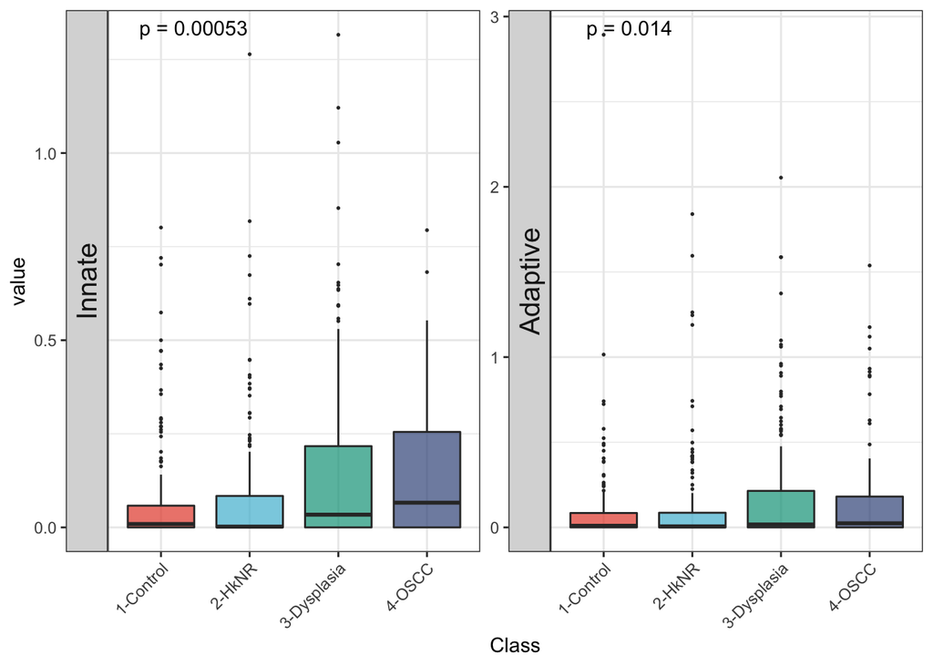

```r
g1 <- ggplot_imm(df = df_est_melted, type="main_cell_types", jitter = F)
g1
```

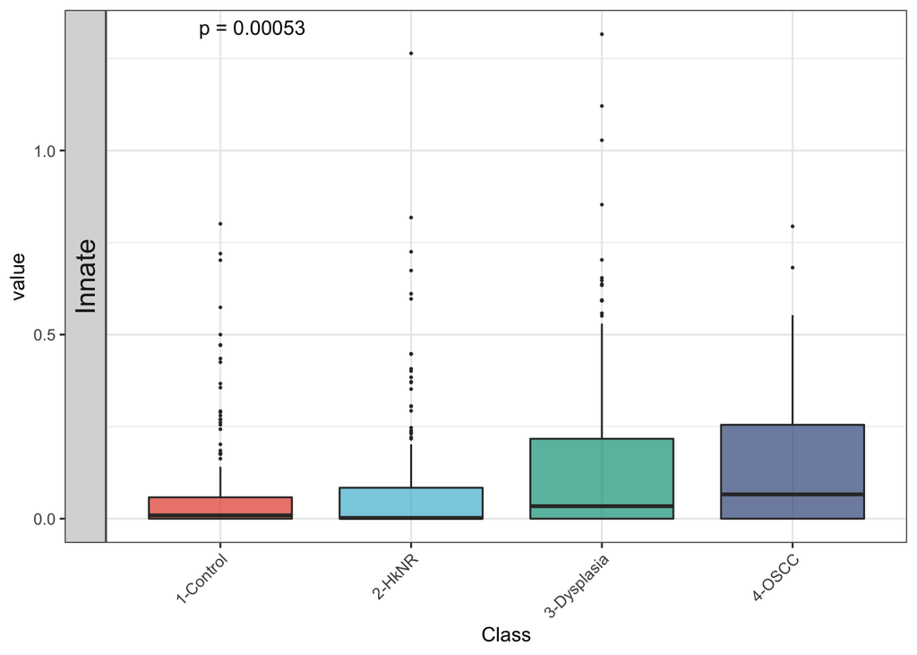

```r
g2 <- ggplot_imm(df =  df_est_melted %>% dplyr::filter(main_cell_types == 'Innate'), type="main_cell_types",  jitter = F)
g2
```

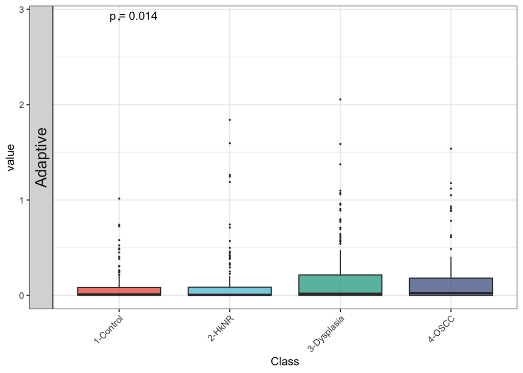

```r
g3 <- ggplot_imm(df =  df_est_melted %>% dplyr::filter(main_cell_types == 'Adaptive'), type="main_cell_types",  jitter = F)
g3
```

```r
ggsave(plot = g2, filename = file.path(PATH, "results/06_22_innate.png"), width = 8, height = 8, dpi = 300)
ggsave(plot = g3, filename = file.path(PATH, "results/06_22_adaptive.png"), width = 8, height = 8, dpi = 300)
```

### Immune breakdown

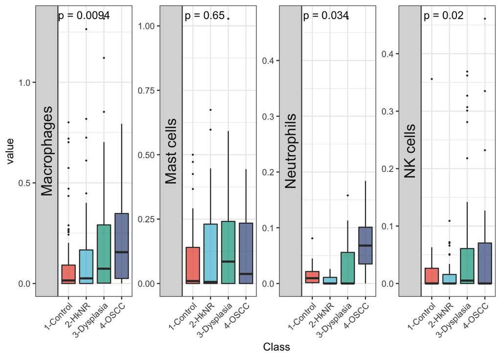

```r
#grouped cell types
g4 <- ggplot_imm(df =  df_est_melted %>% dplyr::filter(grouped_cell_types %in% c("NK cells", "Macrophages", "Mast cells", "Neutrophils")), type="grouped_cell_types",  jitter = F)
g4
```

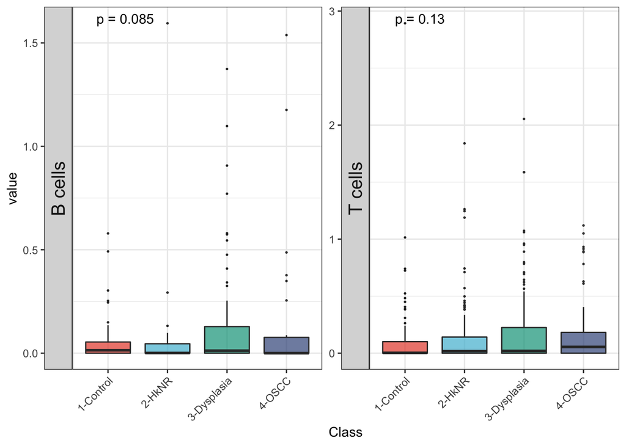

```r
g5 <- ggplot_imm(df = df_est_melted %>% dplyr::filter(!grouped_cell_types %in% c("NK cells", "Macrophages", "Mast cells", "Neutrophils")), type="grouped_cell_types",  jitter = F)
g5
```

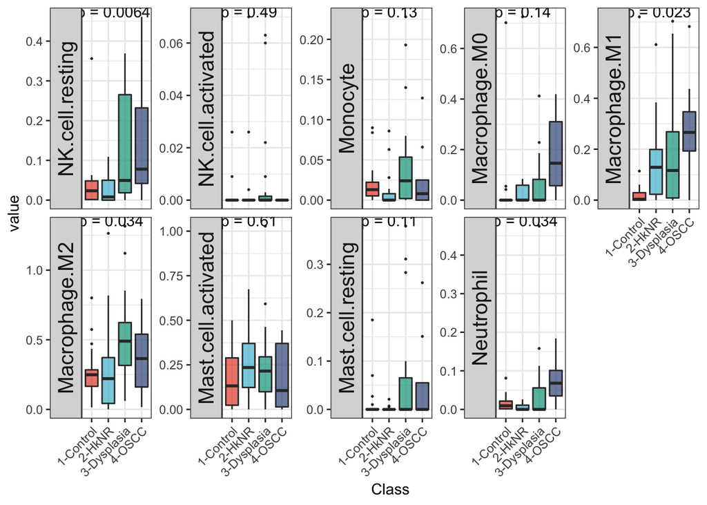

```r
g6 <- ggplot_imm(df = df_est_melted %>% dplyr::filter(grouped_cell_types %in% c("NK cells", "Macrophages", "Mast cells", "Neutrophils")), type="cell_types",  jitter = F)
g6
```

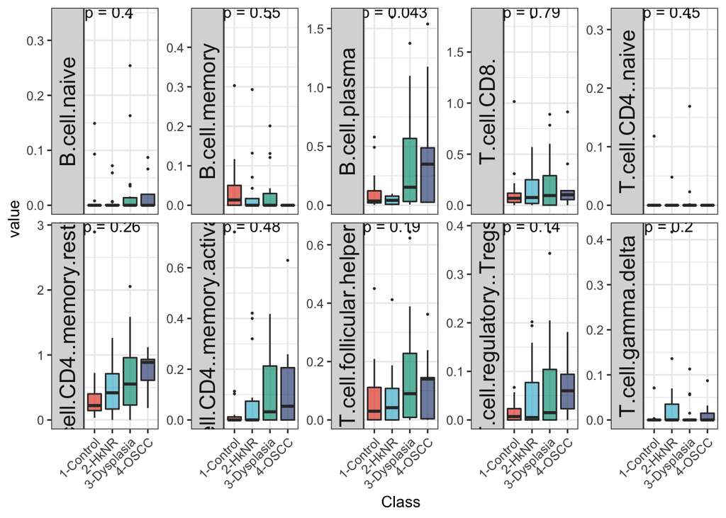

```r
g7 <- ggplot_imm(df_est_melted %>% dplyr::filter(!grouped_cell_types %in% c("NK cells", "Macrophages", "Mast cells", "Neutrophils")), type="cell_types",  jitter = F)
g7
```

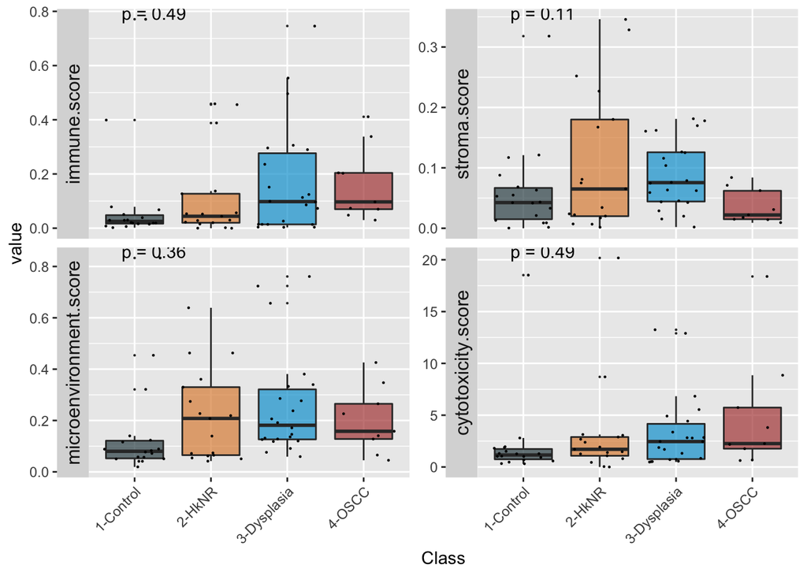

```r
ggsave(plot = g4, filename = file.path(PATH, "results/06_22_grouped_innate.png"), width = 8, height = 4, dpi = 300)
ggsave(plot = g5, filename = file.path(PATH, "results/06_22_grouped_adaptive.png"), width = 5, height = 4, dpi = 300)
ggsave(plot = g6, filename = file.path(PATH, "results/06_22_innate_cell_types.png"), width = 8, height = 6, dpi = 300)
ggsave(plot = g7, filename = file.path(PATH, "results/06_22_adaptive_cell_types.png"), width = 8, height = 6, dpi = 300)


#collective scores
df_est <- data.frame(t(as.matrix(round(est_mat2, digits = 3))))
df_est$Class <- cpm_eset$Class
condition <- 'Class'
cond <- apply(pData(cpm_eset)[, "Class",drop = FALSE], 1, paste, collapse = "_")
df_est[, paste(condition, collapse = "_")] <- cond
df_est_melted2 <- reshape2::melt(df_est,
                              id.vars = "Class",
                              variable.name = "scores")
df_est_melted2$Class <- factor(df_est_melted2$Class, levels=c("1-Control",  "2-HkNR", "3-Dysplasia", "4-OSCC"))
g8 <- ggplot2::ggplot(df_est_melted2, ggplot2::aes(x = Class, y = value, fill = Class)) +
  geom_boxplot(outlier.size =0.1) +
  scale_fill_jama(alpha = 0.7)+
  scale_color_jama(alpha = 0.7)+
  ggplot2::geom_jitter(size=0.15) +
  ggpubr::stat_compare_means(aes(group=Class), method = "anova",  label = 'p.format')+
  ggplot2::facet_wrap(~scores, scale = "free_y",  ncol = 2, strip.position =  "left") +
  ggplot2::theme(axis.text.x = element_text(angle = 45, hjust = 1), strip.text.y  = element_text(size = 12)) +
  theme(legend.position = "none")
g8
```